# Visualizations for article

Lincoln Mullen

November 3, 2015

## Data loading

Read the data.

## Spectrograms

Spectrogram of borrowings in CA1850. I expect it will show heavily reliance on NY1849 amidst original material.

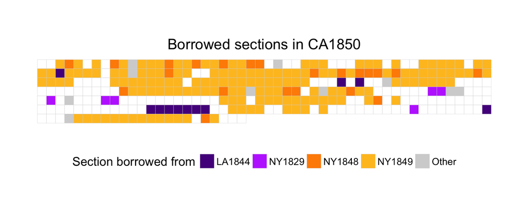

CA1851

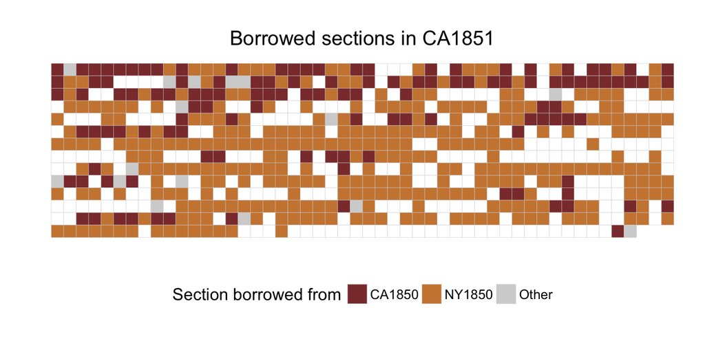

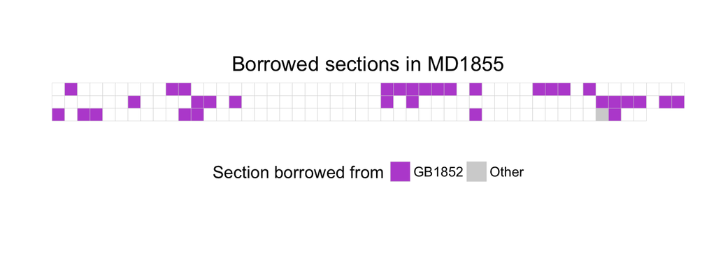

Spectrogram of borrowings in WA1855. An earlier version show two long runs of borrowings from Oregon and Indiana. If the latest data, still visualizes that kind of splicing, I think it’s a great illustration.

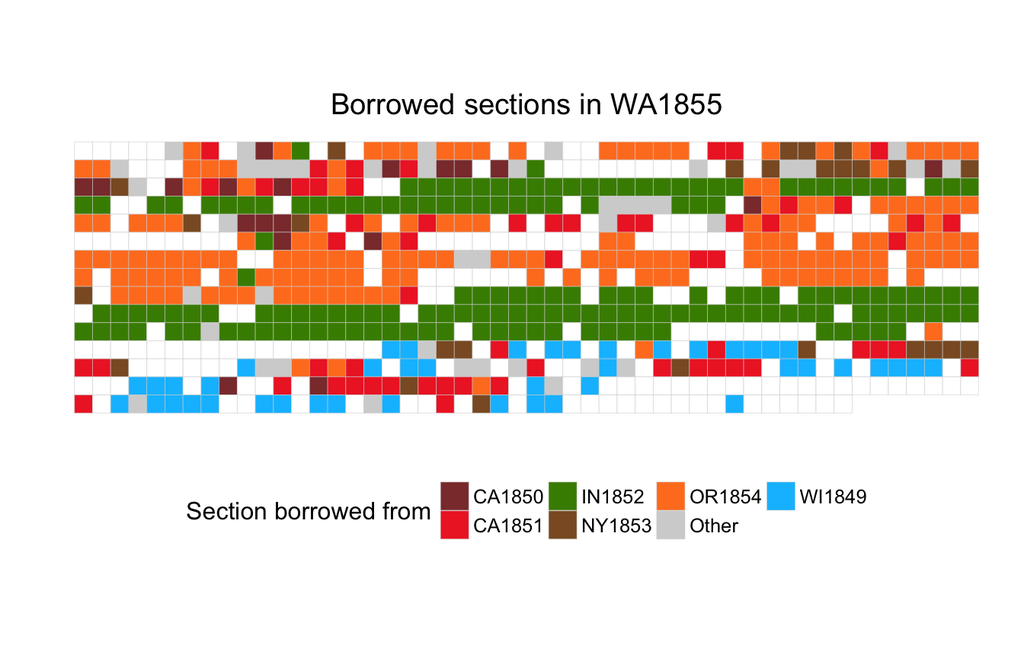

NV1861

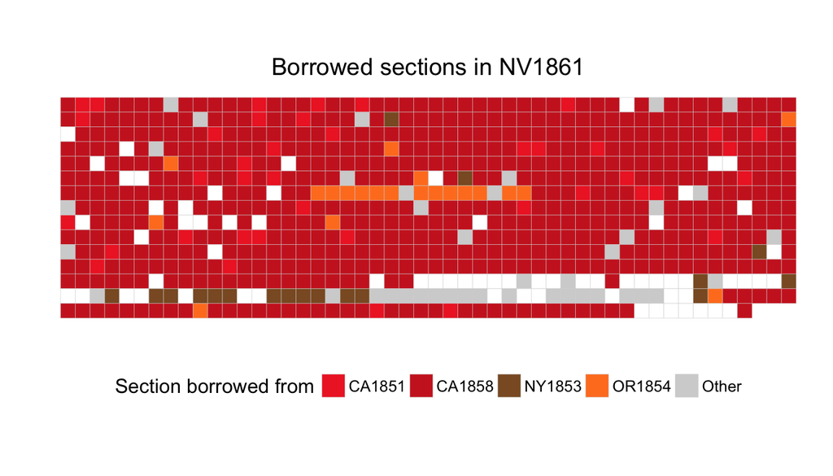

The point of this and the next exercise is not to show borrowings from all sources, but similarity between two sources. Our normal spectrogram of NV1861 will show heavy reliance on California. I want this to show that even though Nevada is two steps away from New York, it’s text is still very similar to New York throughout.

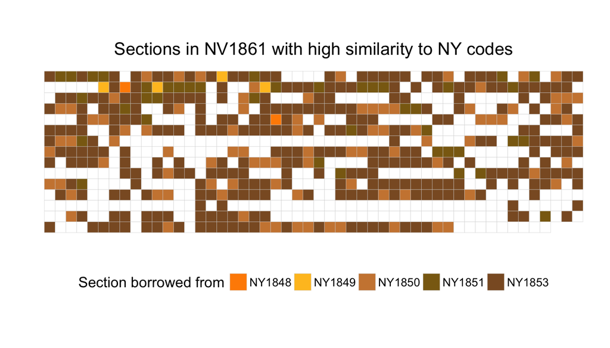

IA1859

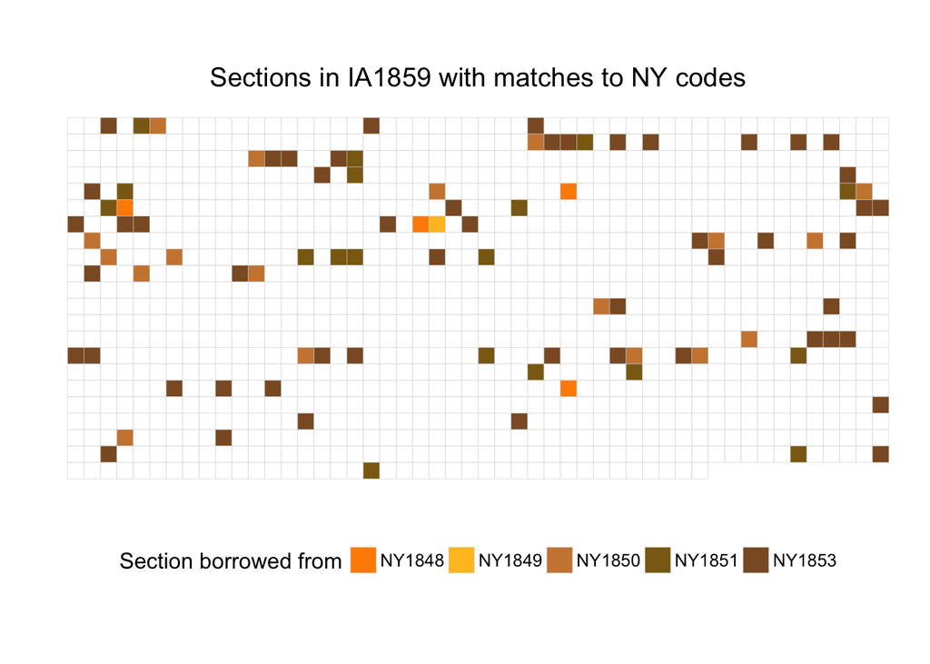

Spectrogram of borrowings in NC1868. Should show heavy reliance on one or another New York Code, with scattered provisions coming from elsewhere.

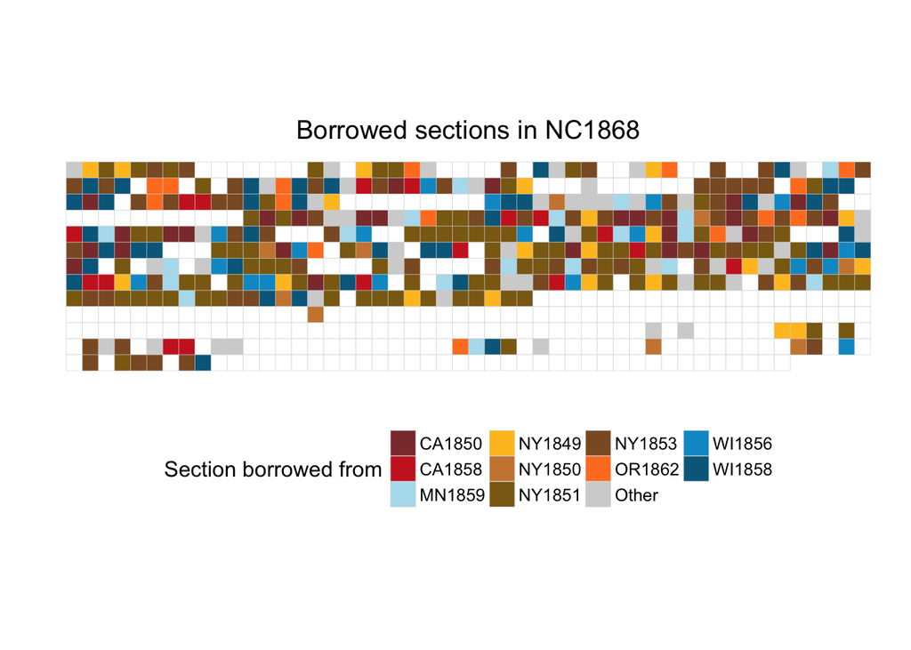

Spectrogram of borrowings in CO1868. Should show heavy reliance on Illinois law.

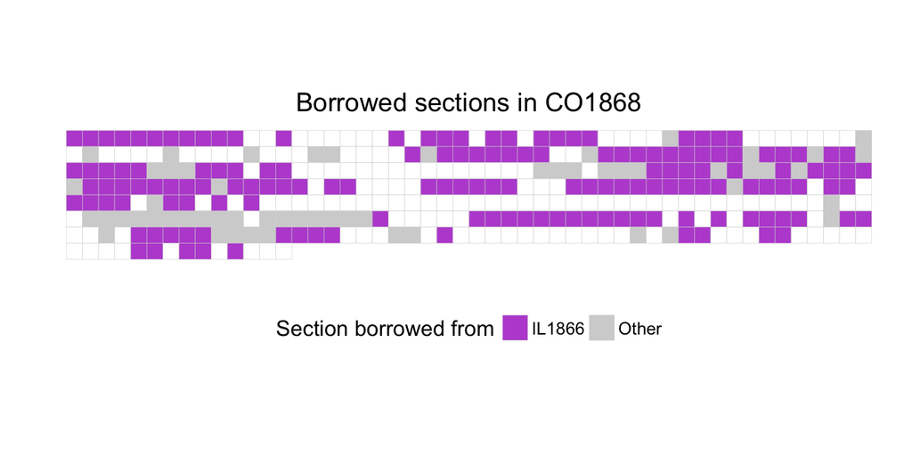

CO1877: companion visualization of Colorado under the Field code

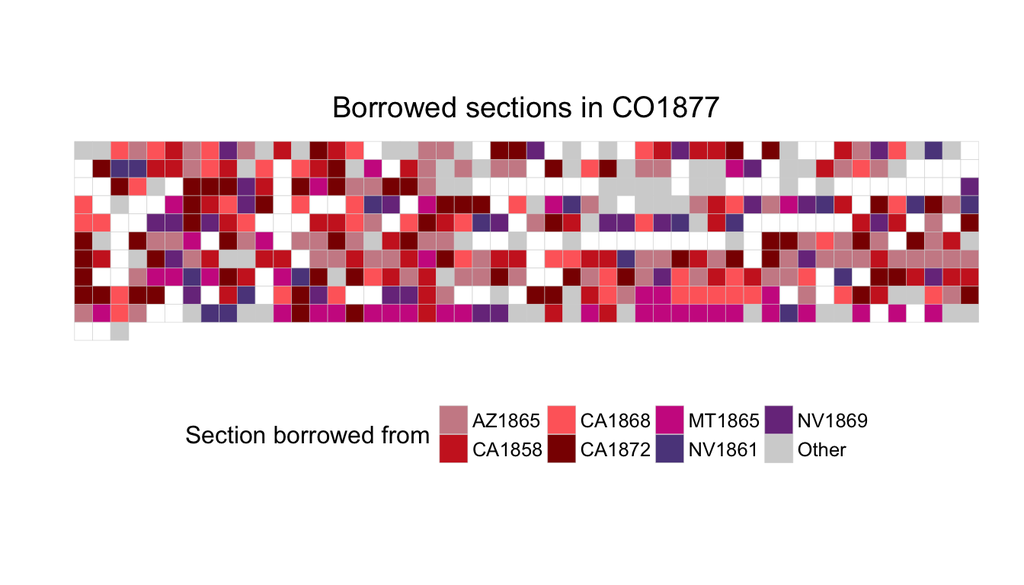

MT 1895

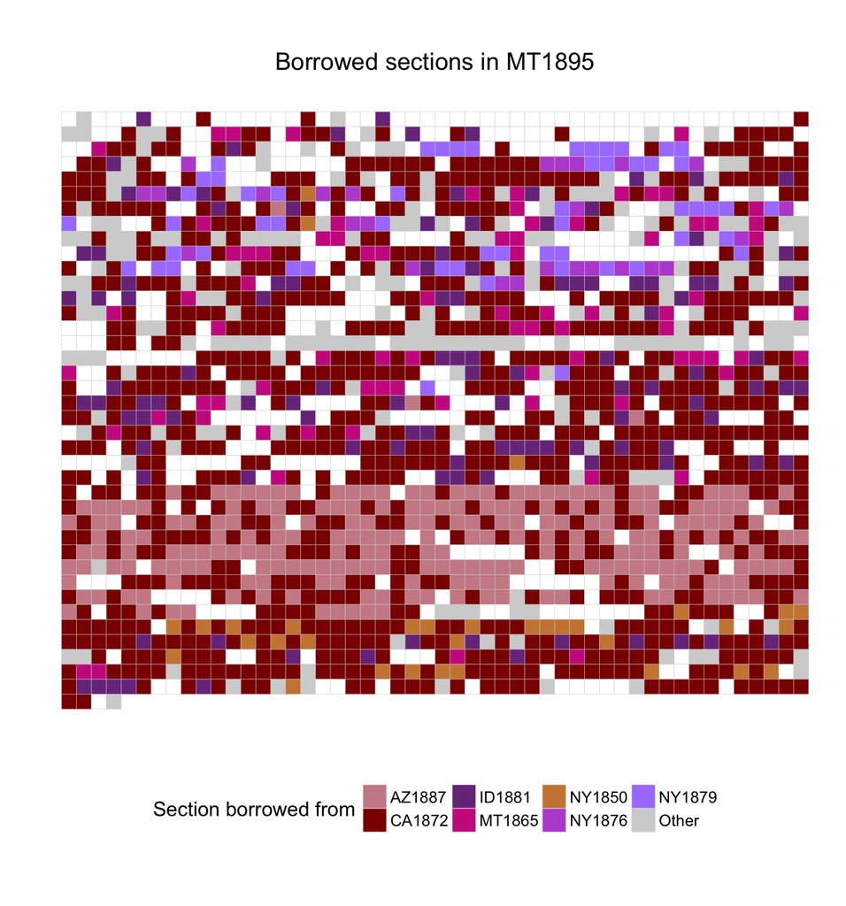

NY1876

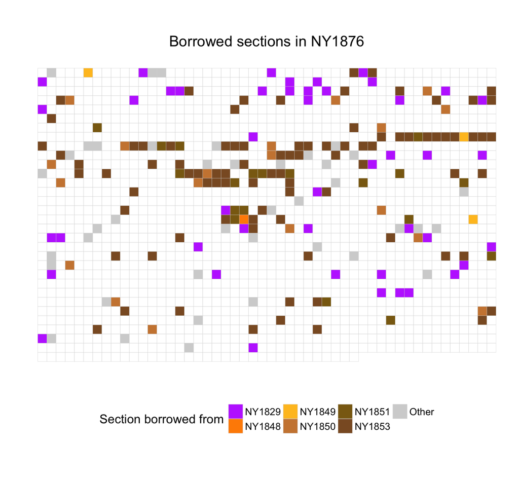

NY1879

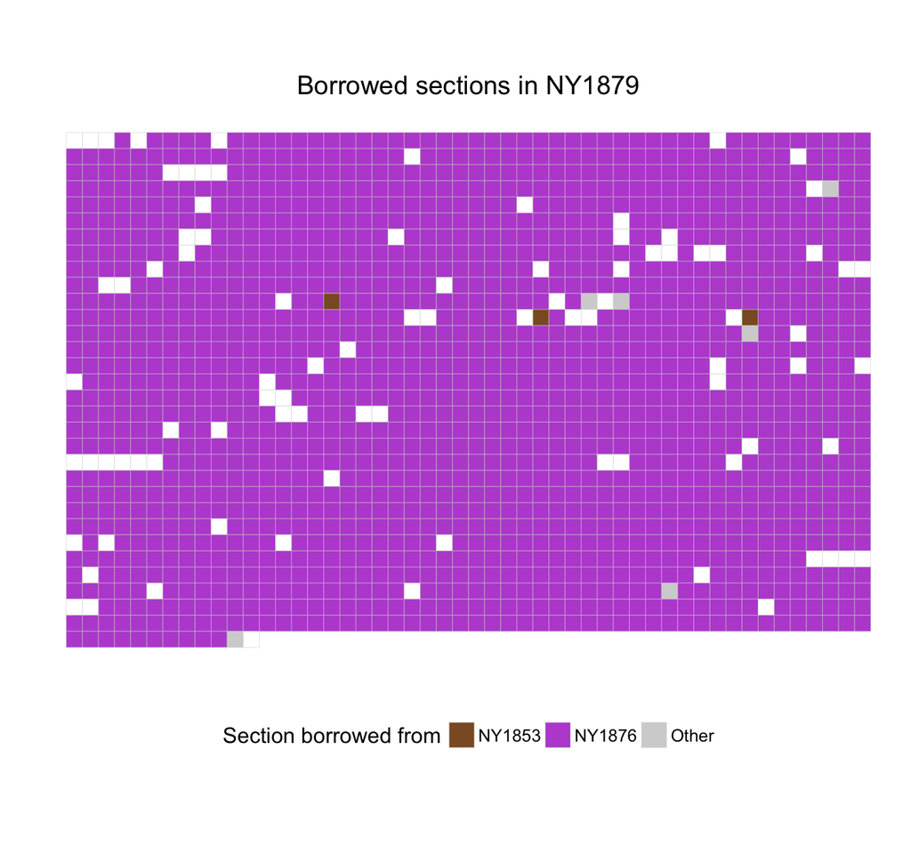

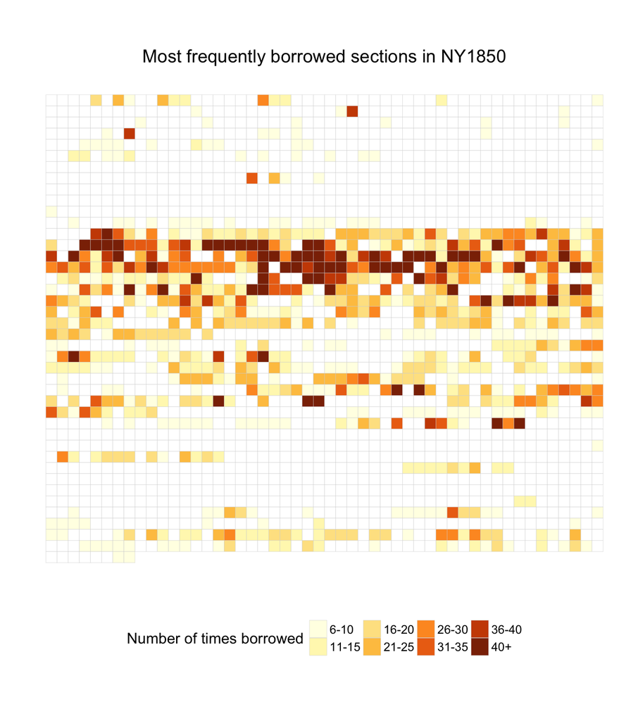